# Part II - what are the factors that impacts whether a person can have a loan or not.

## by Abdulelah

## Investigation Overview

In my project I am interested in figure out what are the factors that ampacts whether a person can have a loan or not.

## Dataset Overview

This [data set](https://www.google.com/url?q=https://s3.amazonaws.com/udacity-hosted-downloads/ud651/prosperLoanData.csv&sa=D&ust=1547699802003000) contains 113,937 loans with 81 variables on each loan, including loan amount, borrower rate (or interest rate), current loan status, borrower income, and many others. This [data dictionary](https://docs.google.com/spreadsheets/d/1gDyi_L4UvIrLTEC6Wri5nbaMmkGmLQBk-Yx3z0XDEtI/edit?usp=sharing) explains the variables in the data set.

The project objective is not expected to explore all of the features in the dataset! But focus on only exploration on about 10 or 15 of them.

## Distribution of each key feature

### Income Range

> Most borrowers have an income between 25,000 and 75,000

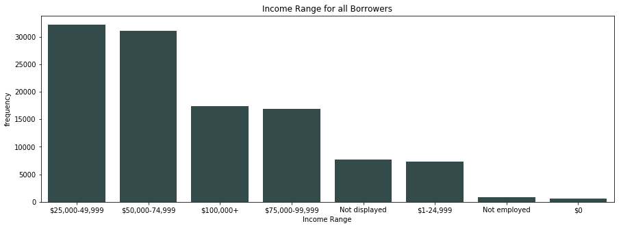

### Homeownership

> half of the borrowers are home owners

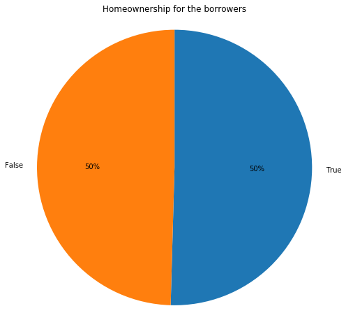

### Employment Status

> Most of the borrowers are employed

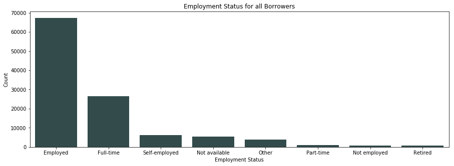

### Borrower Rate & Borrower APR

> Borrower Rate and Borrower APR seemed to have a normal distribution.

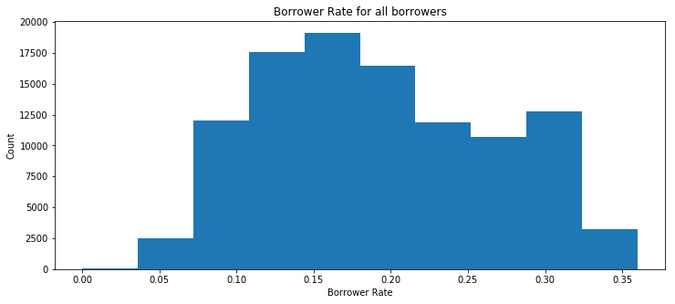

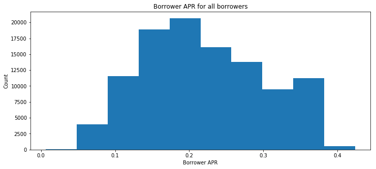

### Loan Original Amount

> we have right-skewed distribution before the log, after that we can see that we have a normal distribution! It's interesting actually!

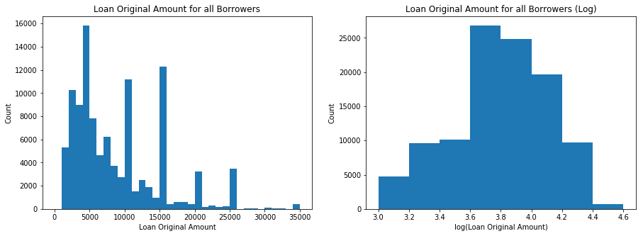

## Relationship among key features (Bivariate)

> The relationship between numerical features, categorical features, and both numerical adn categorical features.

### Between Numerical Features

> BorrowerAPR and BorrowerRate are highly correlated, also LoanOriginalAmount with MonthlyLoanPayment are also highly correlated.

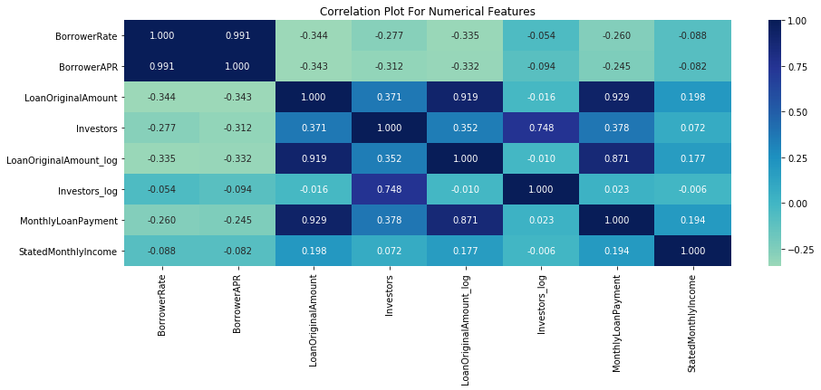

### Between Employment Status & Income Range

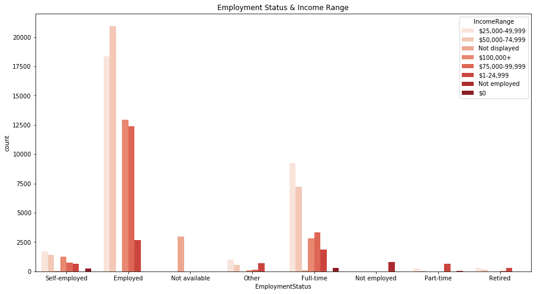

### Between Employment Status & Loan Amount

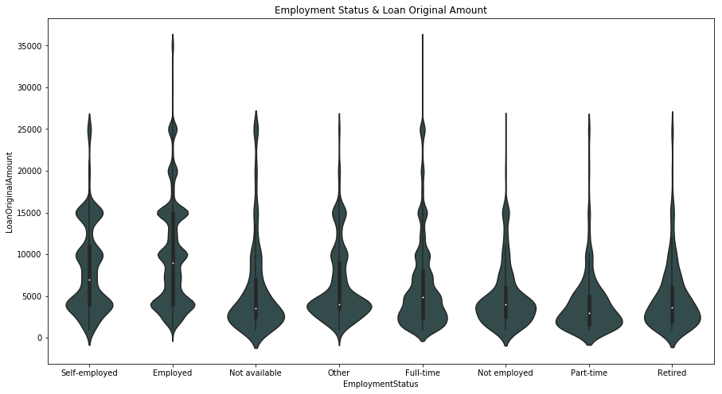

### Between Income Range & Loan Amount

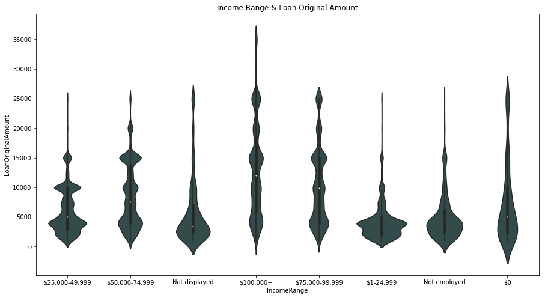

### Between Homeownership & Loan Amount

> home owners borrowers are more likely to have larger loan amount than borrowers that they are not home owners.

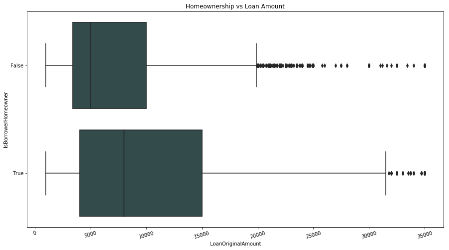

## Relationship among key features (Multivariate)

### Between Homerownership & Employment Status & Loan Amount

> home owner borrowers and employed are having highest amount of a loan, and borrowers with no home to own still having larger amount of loans.

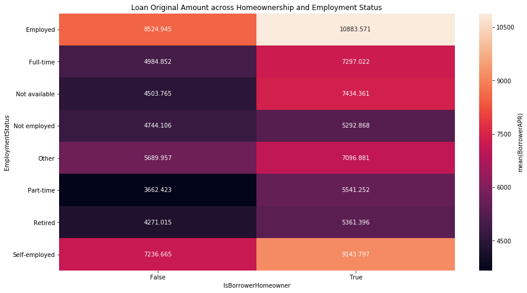

### Between Loan Amount & Homeiwnership & Employment Status

> the plot shows that home owner borrowers and employed are most likely to have a higher amount

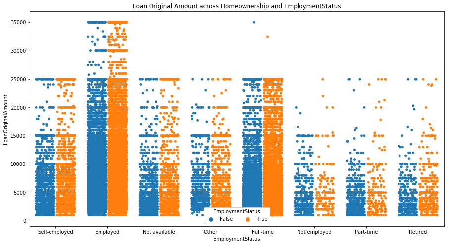

### Between Employment Status & Borrower Rate & Homeownership

> Home owner borrowers have lower rate whatever the employment status is expect unemployed borrowers. home owner and unemployed borrowersare most likely to have higher rate than who's not homeowners.

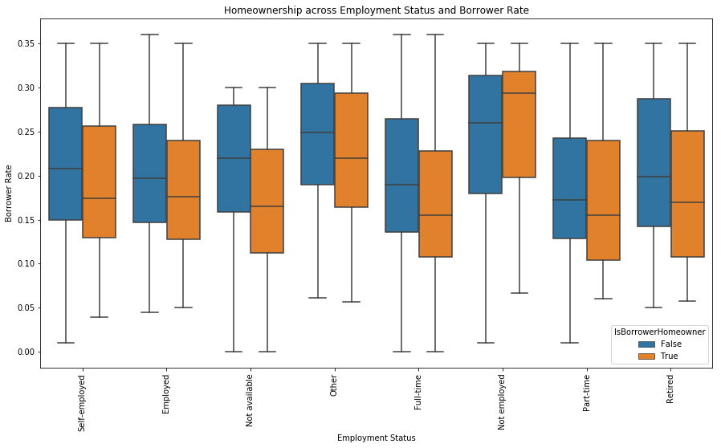